# hemolysin

## Figure 5: Per-residue ΔΔG fold-preference contribution

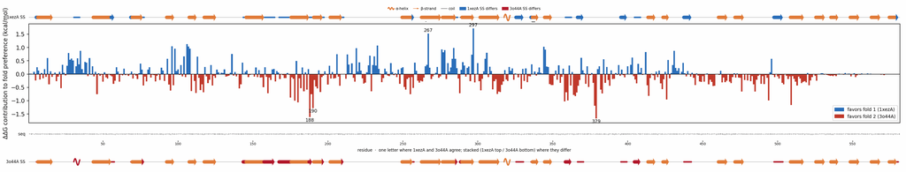

**More figures**

## Figure 6: Deep-MSA contact map panel / Best clusters contact map panel

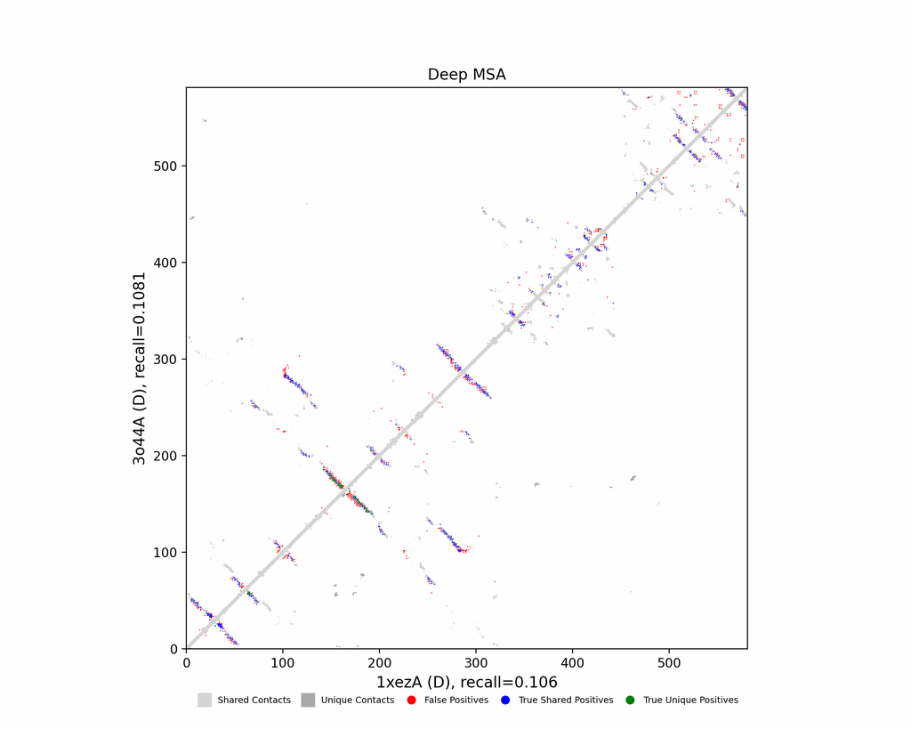

Deep-MSA contact map panel

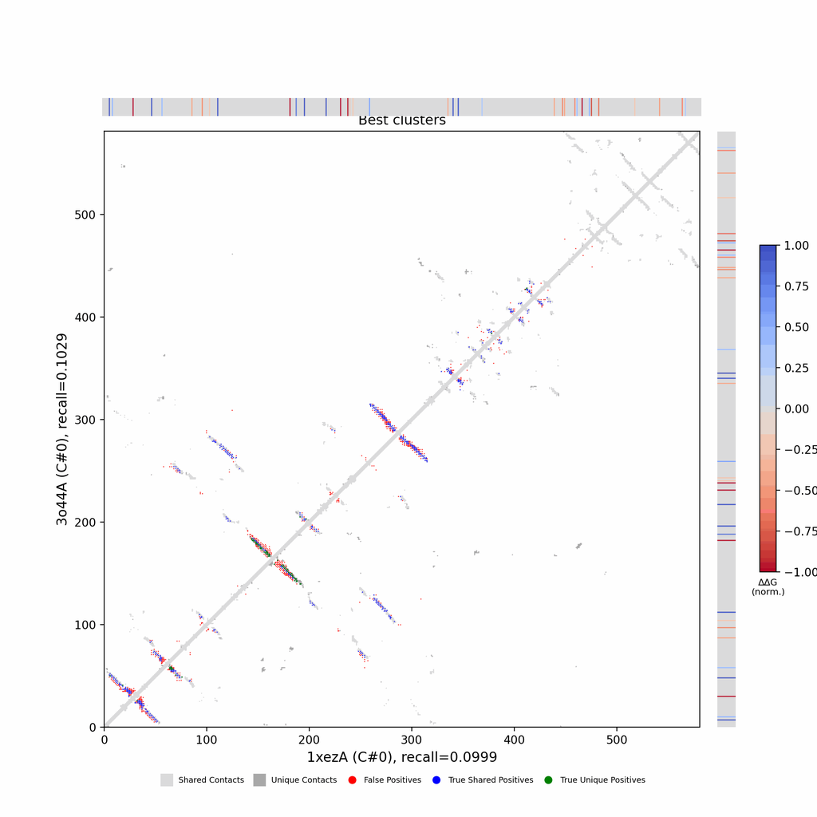

Best clusters contact map panel

## Figure 7: All clusters contact-map mosaic (small multiples).

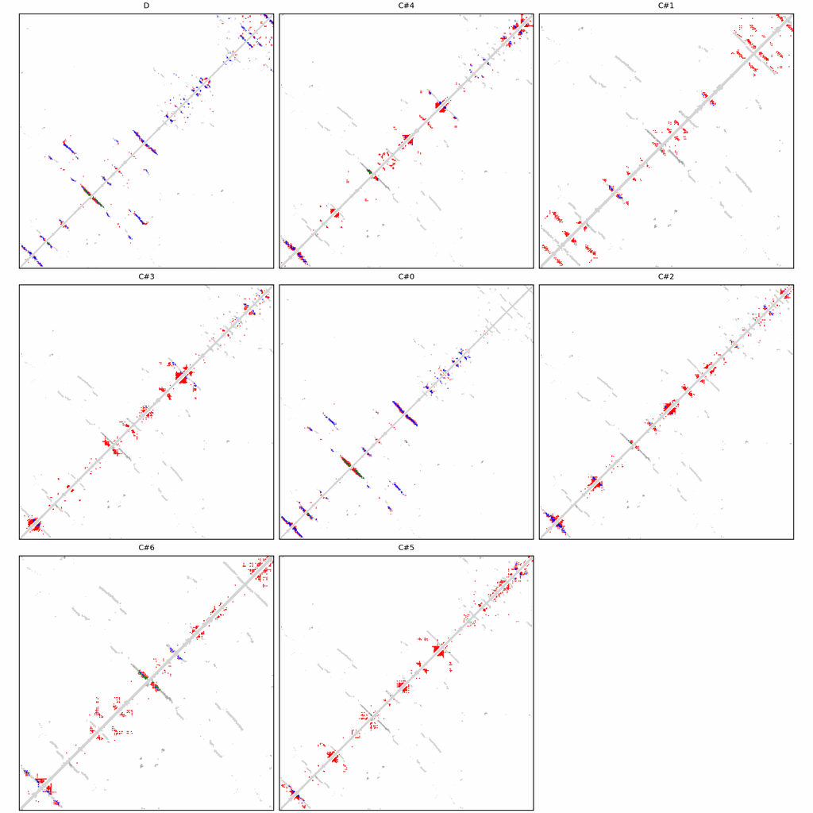

## Figure 8: Phylo null: tree with shuffled cluster fold labels.

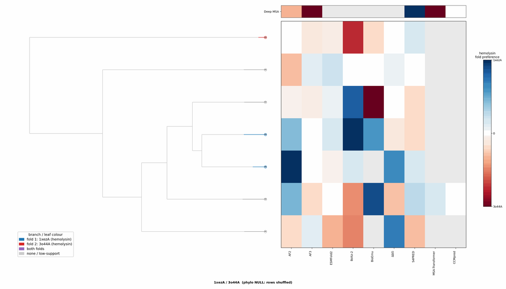

## Cluster metrics table

Per-cluster metrics underlying the figures above.

| cluster | n | neff | AF2_TM1 | AF2_TM2 | AF3_TM1 | AF3_TM2 | RE-MSAT-COM | RE-MSAT1 | RE-MSAT2 | ESM_SEQIDS | ESM_TM1 | ESM_TM2 | ΔΔG_Bias | ΔΔG_Bias_std | ΔΔG_frac_F1 | Boltz2_pref | S4PRED_pref | CCMpred_pref | BioEmu_pref |
| --- | --- | --- | --- | --- | --- | --- | --- | --- | --- | --- | --- | --- | --- | --- | --- | --- | --- | --- | --- |
| Deep | - | - | 0.64 | 0.67 | 0.62 | 0.88 | 0.19 | 0.17 | 0.19 | - | - | - | - | - | - | - | 0.04 | 0.0 | - |
| 000 | 283.0 | 59.0 | 0.18 | 0.16 | 0.19 | 0.25 | 0.2 | 0.2 | 0.21 | 002; 006; 001; 010; 004; 008; 005; 007; 003; 009 | 0.38 ± 0.13 | 0.41 ± 0.15 | -35.97 | 20.99 | 0.0 | -0.04 | 0.03 | 0.0 | -0.01 |
| 001 | 10.0 | 7.0 | 0.24 | 0.29 | 0.38 | 0.37 | 0.02 | 0.02 | 0.02 | - | - | - | -0.26 | 4.85 | 0.4 | -0.02 | 0.01 | - | - |
| 002 | - | - | 0.18 | 0.23 | 0.21 | 0.2 | 0.01 | 0.01 | 0.01 | - | - | - | -23.51 | 13.94 | 0.0 | -0.02 | 0.02 | - | -0.02 |
| 003 | - | - | 0.28 | 0.31 | 0.33 | 0.37 | 0.01 | 0.01 | 0.01 | - | - | - | -25.31 | 14.43 | 0.0 | 0.01 | 0.01 | - | -0.04 |
| 004 | - | - | 0.34 | 0.33 | 0.41 | 0.43 | 0.03 | 0.04 | 0.03 | - | - | - | -29.22 | 15.94 | 0.0 | 0.02 | 0.01 | - | -0.02 |
| 005 | - | - | 0.19 | 0.22 | 0.36 | 0.4 | 0.02 | 0.01 | 0.02 | - | - | - | -25.51 | 12.58 | 0.0 | -0.05 | 0.02 | - | -0.02 |
| 006 | 10.0 | 2.0 | 0.26 | 0.2 | 0.22 | 0.24 | 0.01 | 0.02 | 0.02 | - | - | - | -2.64 | 2.87 | 0.0 | -0.01 | 0.02 | - | - |